# Data 621 Homework 1: Moneyball

Critical Thinking Group 2 - Armenoush Aslanian-Persico, James Topor, Jeff Nieman, Scott Karr

**————————————————————————————————————————–**

# Part 1: Data Exploration

## Data Summary

| variables | n | mean | sd | med | min | max | range | skew | kurtosis | se | NAs |
| --- | --- | --- | --- | --- | --- | --- | --- | --- | --- | --- | --- |
| INDEX | 2276 | 1268 | 736 | 1271 | 1 | 2535 | 2534 | 0.00 | -1.22 | 15.43 |  |
| TARGET_WINS | 2276 | 81 | 16 | 82 | 0 | 146 | 146 | -0.40 | 1.03 | 0.33 |  |
| TEAM_BATTING_H | 2276 | 1470 | 145 | 1454 | 891 | 2554 | 1663 | 1.57 | 7.28 | 3.03 |  |
| TEAM_BATTING_2B | 2276 | 241 | 47 | 238 | 69 | 458 | 389 | 0.22 | 0.01 | 0.98 |  |
| TEAM_BATTING_3B | 2276 | 55 | 28 | 47 | 0 | 223 | 223 | 1.11 | 1.50 | 0.59 |  |
| TEAM_BATTING_HR | 2276 | 100 | 61 | 102 | 0 | 264 | 264 | 0.19 | -0.96 | 1.27 |  |
| TEAM_BATTING_BB | 2276 | 502 | 123 | 512 | 0 | 878 | 878 | -1.03 | 2.18 | 2.57 |  |
| TEAM_BATTING_SO | 2174 | 736 | 240 | 750 | 0 | 1399 | 1399 |  |  |  | 102 |
| TEAM_BASERUN_SB | 2145 | 125 |  | 101 | 0 | 697 | 697 |  |  |  | 131 |
| TEAM_BASERUN_CS | 1504 | 53 | 23 | 49 | 0 | 201 | 201 | 1.98 | 7.62 | 0.59 | 772 |
| TEAM_BATTING_HBP | 191 | 59 | 13 | 58 | 29 | 95 | 66 | 0.32 | -0.11 | 0.94 | 2085 |
| TEAM_PITCHING_H | 2276 | 1779 | 1407 | 1518 | 1137 | 30132 | 28995 | 10.33 | 141.84 | 29.49 |  |
| TEAM_PITCHING_HR | 2276 | 106 | 61 | 107 | 0 | 343 | 343 | 0.29 | -0.60 | 1.28 |  |
| TEAM_PITCHING_BB | 2276 | 553 | 166 | 536 | 0 | 3645 | 3645 | 6.74 | 96.97 | 3.49 |  |
| TEAM_PITCHING_SO | 2174 | 818 | 553 | 813 | 0 | 19278 | 19278 | 22.17 | 671.19 | 11.86 | 102 |
| TEAM_FIELDING_E | 2276 | 246 | 228 | 159 | 65 | 1898 | 1833 | 2.99 | 10.97 | 4.77 |  |
| TEAM_FIELDING_DP | 1990 | 146 | 26 | 149 | 52 | 228 | 176 | -0.39 | 0.18 | 0.59 | 286 |

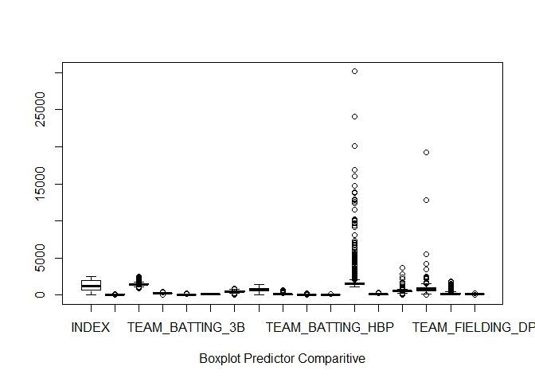

## Correlation Plot

Using the cor function across the data frame we noticed some strong correlations. TEAM_BATTING_H obviously has some colinearity with TEAM_BATTING_2B, TEAM_BATTING_3B and TEAM_BATTING_HR as these values are a subset of hits. TEAM_BATTING_BB and TEAM_PITCHING_BB have strong correlations and so do TEAM_PITCHING_HR and TEAM_BATTING_HR. Since we are most concerned with wins, the following table shows the correlation when the NA’s are ommited:

| Value | Correlation with Wins |
| --- | --- |
| TEAM_BATTING_H | 0.46994665 |
| TEAM_BATTING_2B | 0.31298400 |
| TEAM_BATTING_3B | -0.12434586 |
| TEAM_BATTING_HR | 0.42241683 |
| TEAM_BATTING_BB | 0.46868793 |
| TEAM_BATTING_SO | -0.22889273 |
| TEAM_BASERUN_SB | 0.01483639 |
| TEAM_BASERUN_CS | -0.17875598 |
| TEAM_BATTING_HBP | 0.07350424 |
| TEAM_PITCHING_H | 0.47123431 |
| TEAM_PITCHING_HR | 0.42246683 |
| TEAM_PITCHING_BB | 0.46839882 |
| TEAM_PITCHING_SO | -0.22936481 |
| TEAM_FIELDING_E | -0.38668800 |
| TEAM_FIELDING_DP | 0.13168916 |

As a result of missing data, severe outliers, and collinearity shown above there is a clear need for some data preparation and transformation.

**————————————————————————————————————————–**

# Part 2: Data Preparation

Our data preparation efforts for the training data set consisted of the creation of one new derived variable, removing four predictor variables, imputing values for the remaining variables that had missing values (NA’s), and removal of a relatively small number of records that contained clearly egregious outlier values for particular variables. The results of these efforts were subsequently used as the basis for each of the five different linear models we created and evaluated.

## New Variable Creation

We began our data preparation efforts by creating a new variable TEAM_BATTING_1B which represents offensive single base hits. The variable was created by subtracting out the TEAM_BATTING doubles, triples and home runs from the TEAM_BATTING_H variable.

The TEAM_BATTING_H variable was then dropped from the data set. We believe that separating out singles from the other unique hit values will minimize collinearity.

## Removal of Variables Due to Collinearity and/or Missing Values

The results of our data exploration efforts led us to drop three other variables from the data set:

These same three variables were subsequently removed from the Evaluation data set to ensure compatibility with our linear models.

## Imputation of Missing Values (NA’s)

### Filling Missing values in the Training Data Set

We then worked on imputing the remaining missing data. To do this we made use of a linear regression approach recommended by Faraway (p.201) and Fox (p.611). We decided against the using the mean or median as a replacement value for NA’s since regression yields imputed values that are much more consistent with the actual distribution of the data while introducing much less potential bias than use of a mean or median would incur.

We built regression imputation models for the variables listed below. Each model was analyzed to ensure that there were no collinearity issues and all p-values were < $.05$. While we did not not have the time or resources to run a complete cadre of residual diagnostics on these imputation models, we did verify that their results produced imputed distributions of the subject variables that were consistent with those of the original NA-populated data. It is our belief that this consistency indicates that the resulting predicted values for the missing values are better to use than simply filling the NA’s with a mean or median.

### Filling Missing Values in the Evaluation Data Set

These four imputation regression models were then used to populate missing values for the same variables within the evaluation data set. Clearly, any models we might have constructed for purposes of predicting WINS for the evaluation set would have failed to work on any records within that data set that contained NA’s. Applying the imputation models to the evaluation data allows us to avoid that problem.

## Removal of Extreme Outliers From the Training Data Set

We completed our data preparation efforts by eliminating some clearly egregious outliers identified via research through *baseball-almanac.com*. This approach is suggested by Sheather (p. 57). For example, the record for the most pitching strikeouts in a single season is 1450 by the 2014 Cleveland Indians. Therefore we know that any records having TEAM_PITCHING_SO values above that point is an aberration, and any records containing such values were summarily removed from the data set.

Similarly, the most errors by team in a single season was 639 by Philadelphia in 1883. Prorating to 162 games we calculated that we should discard any records containing TEAM_FIELDING_E values above 1046.

The TEAM_PITCHING_H variable also appeared to have numerous egregious outliers. For example, the most offensive hits by a team in a single season was 1730. As such, it is highly unlikely that any pitching staff would surrender more than 3000 hits in a single season since such a total would indicate the team was allowing more than 18 hits per game. As such, any records having a TEAM_PITCHING_H value > 3000 was removed from the data set.

Removing the egregious outliers resulting in a sum total of 104 records being removed from the training data set. Removal of these outliers helped to normalize our data and thereby improve the expected performance of our linear models.

## Results of Imputation for Missing Values and Outlier Removal Process

The end results of our data transformation process dramatically improved the data as you can see from the following plot. There still are a few outliers but there are on a much smaller scale.

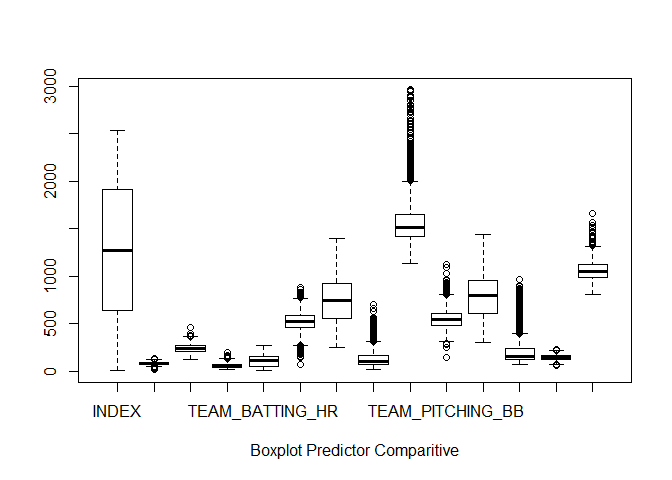

Our training data set with the NA’s filled and the outliers removed can be found here:

https://github.com/spsstudent15/2016-02-621-W1/blob/master/621-HW1-Clean-Data.csv

Our Evaluation data set with the NA’s filled can be found here:

https://github.com/spsstudent15/2016-02-621-W1/blob/master/621-HW1-Clean-EvalData-.csv

## Other Data Prepation Transformations: Refer to Model Descriptions

Other *model-specific* data transformations were also used, including use of Box-Cox power transforms and linear combinations of variables. These model-specific transformations are discussed within the individual model writeups provided in **Part 3**.

**————————————————————————————————————————–**

# Part 3: Build Models

## Model 1: General Model Using Backward Selection

This model applies simple Backward Selection methods through the use of p-values and variance inflation factors (VIF) against the following predictor variables:

- TEAM_BATTING_1B (derived variable)
- TEAM_BATTING_2B
- TEAM_BATTING_3B
- TEAM_BATTING_HR
- TEAM_BATTING_BB
- TEAM_BATTING_SO
- TEAM_BASERUN_SB
- TEAM_PITCHING_H
- TEAM_PITCHING_BB
- TEAM_PITCHING_SO
- TEAM_FIELDING_E
- TEAM_FIELDING_DP

Simply removing the *TEAM_BATTING_1B* variable yielded a model with all p-values less than $.05$. However, VIF analysis showed evidence of multiple collinear variables within the model. Subsequent removals of *TEAM_PITCHING_SO* and *TEAM_PITCHING_BB* due to collinearity yielded a model that called for the removal of *TEAM_BATTING_2B* on the basis of its p-value.

The final model of that iteration of the linear modeling process showed clear evidence of a number of outliers as evidenced in R’s summary diagnostic plots. Those outliers were removed via a series of additional iterations yielding the following final model, which varies from the inital iteration in that it includes *TEAM_BATTING_2B* due to the fact that removing the outliers improved the statistical significance of the variable :

| Coefficient | Variable |
| --- | --- |
| 66.261 | Intercept |
| - 0.017 | TEAM_BATTING_2B |
| + 0.150 | TEAM_BATTING_3B |
| + 0.109 | TEAM_BATTING_HR |
| + 0.022 | TEAM_BATTING_BB |
| - 0.019 | TEAM_BATTING_SO |
| + 0.065 | TEAM_BASERUN_SB |
| + 0.016 | TEAM_PITCHING_H |
| - 0.075 | TEAM_FIELDING_E |
| - 0.109 | TEAM_FIELDING_DP |

| RSE | R^2 | Adj. R^2 | F Stat. | MSE |
| --- | --- | --- | --- | --- |
| 11.49 | 0.3598 | 0.3572 | 134.4 | 132 |

However, the diagnostic plots of that model showed a lack of linearity between the response variable TARGET_WINS and the predictor variable TEAM_FIELDING_E as evidenced in the Added Variable plots shown in the Appendix. Furthermore, the plots of standardized residuals against each of the predictor variables showed evidence of non-constant variability for variables such as TEAM_BATTING_HR, TEAM_BATTING_SO, TEAM_BASERUN_SB, and TEAM_FIELDING_E.

The TEAM_FIELDING_E variable was subsequently transformed using a Box-Cox recommended power transform of (-1), or (1/y) and the model was re-run. The resulting Added Variable plots showed that all predictors are linearly related to the response, and we see an improvement in the variability of the residuals relative to TEAM_FIELDING_E. Furthermore, the plot of Y against the fitted values showed an improvement in the linearity of the model.

Therefore, this model appears to be an improvement over the first model when the residual plots are considered. The characteristic equation indicated by the model is as follows:

| Coefficient | Variable |
| --- | --- |
| 52.88 | Intercept |
| + 0.168 | TEAM_BATTING_3B |
| + 0.096 | TEAM_BATTING_HR |
| + 0.027 | TEAM_BATTING_BB |
| - 0.027 | TEAM_BATTING_SO |
| + 0.034 | TEAM_BASERUN_SB |
| + 0.004 | TEAM_PITCHING_H |
| + 3252.31 | 1/TEAM_FIELDING_E |
| - 0.102 | TEAM_FIELDING_DP |

| RSE | R^2 | Adj. R^2 | F Stat. | MSE |
| --- | --- | --- | --- | --- |
| 11.86 | 0.3168 | 0.3143 | 124.8 | 141 |

While this model is an improvement over the initial model, we still have component variables that appear to lack constant variability relative to the residuals for variables such as TEAM_BASERUN_SB. The lack of constant variability in the residuals is likely related to the skewed nature of the distributions of those individual variables.

In the other models discussed herein we attempt to address some of the skew issues via various methods, including Box-Cox recommended power transforms and linear combinations of various variables.

**————————————————————————————————————————–**

## Model 2: Total Bases

This model attempts to address some of the lack of constant variability found in the “General Model” discussed above by employing a linear combination of four of the predictor variables to calculate the baseball statistc known as “Total Bases”. Total Bases is calculated using what our data set refers to as “TEAM_BATTING” variables as follows:

- Singles + (2 * Doubles) + (3 * Triples) = (4 * Home Runs)

Inclusion of this new variable allows us to eliminate the four component variables from the model. In fact, the TOTAL_BASES variable appears to be nearly normally distributed, thereby negating the skew issues that were evident with its component variables.

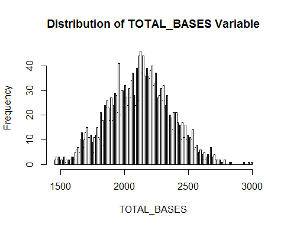

This model applies simple Backward Selection methods through the use of p-values and variance inflation factors (VIF) against the following predictor variables:

- TEAM_TOTAL_BASES (derived variable)
- TEAM_BATTING_BB
- TEAM_BATTING_SO
- TEAM_BASERUN_SB
- TEAM_PITCHING_H
- TEAM_PITCHING_BB
- TEAM_PITCHING_SO
- TEAM_FIELDING_E
- TEAM_FIELDING_DP

Three iterations of p-value / VIF backward selection removed TEAM_PITCHING_SO and TEAM_PITCHING_BB from the model. All other variables remained statistically significant with no signficant collinearity. However, evidence of multiple outliers was found via R’s summary diagnostic plots. Those outliers were removed via a series of additional iterations yielding the following final model:

| Coefficient | Variable |
| --- | --- |
| 48.486 | Intercept |
| + 0.022 | TEAM_BATTING_BB |
| - 0.015 | TEAM_BATTING_SO |
| + 0.063 | TEAM_BASERUN_SB |
| + 0.010 | TEAM_PITCHING_H |
| - 0.064 | TEAM_FIELDING_E |
| - 0.117 | TEAM_FIELDING_DP |
| + 0.018 | TOTAL_BASES |

| RSE | R^2 | Adj. R^2 | F Stat. | MSE |
| --- | --- | --- | --- | --- |
| 11.7 | 0.3365 | 0.3343 | 156 | 137 |

The diagnostic plots of that model show a lack of linearity between the response variable TARGET_WINS and the predictor variable TEAM_FIELDING_E as evidenced in the Added Variable plots shown in the Appendix. Furthermore, the plots of standardized residuals against each of the predictor variables showed evidence of non-constant variability for variables such as TEAM_BATTING_SO, TEAM_BASERUN_SB, and TEAM_FIELDING_E.

The TEAM_FIELDING_E variable was subsequently transformed using a Box-Cox recommended power transform of (-1), or (1/y) and the model was re-run. The resulting Added Variable plots show that all predictors are linearly related to the response, and we see an improvement in the variability of the residuals relative to TEAM_FIELDING_E. Furthermore, the plot of Y against the fitted values shows an improvement in the linearity of the model.

Therefore, this model appears to be an improvement over the first TOTAL_BASES model when the residual plots are considered. The characteristic equation indicated by the model is as follows:

| Coefficient | Variable |
| --- | --- |
| 39.164 | Intercept |
| + 0.025 | TEAM_BATTING_BB |
| - 0.025 | TEAM_BATTING_SO |
| + 0.038 | TEAM_BASERUN_SB |
| + 2714.54 | 1/TEAM_FIELDING_E |
| - 0.115 | TEAM_FIELDING_DP |
| + 0.0197 | TOTAL_BASES |

| RSE | R^2 | Adj. R^2 | F Stat. | MSE |
| --- | --- | --- | --- | --- |
| 11.97 | 0.3048 | 0.3029 | 157.5 | 143 |

**————————————————————————————————————————–**

## Model 3: Total Bases PLUS

This model attempts to improve upon the results of the “Total Bases” model by extending the TOTAL_BASES variable to include the TEAM_BATTING_BB and TEAM_BASERUN_SB variables. The logic behind adding these two variables to the TOTAL_BASES variable comes from the fact that both, like the component variables of TOTAL_BASES, represent basepath advancements by a team’s offense.

“Total Bases Plus”" (referred to as TB_PLUS hereon) is calculated using what our data set refers to as “TEAM_BATTING” and “TEAM_BASERUN” variables as follows:

- Singles + (2 * Doubles) + (3 * Triples) = (4 * Home Runs) + BB + SB

Inclusion of this new variable allows us to eliminate the two additional component variables from the model. In fact, the TB_PLUS variable, like the TOTAL_BASES variable used earlier appears to be nearly normally distributed, thereby negating the skew issues that were evident with its component variables. A histogram of the distribution of the derived TB_PLUS variable is shown below:

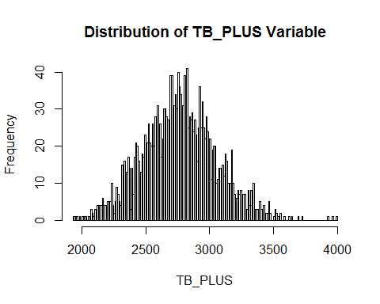

This model applies simple Backward Selection methods through the use of p-values and variance inflation factors (VIF) against the following predictor variables:

- TB_PLUS (derived variable)
- TEAM_BATTING_SO
- TEAM_PITCHING_H
- TEAM_PITCHING_BB
- TEAM_PITCHING_SO
- TEAM_FIELDING_E
- TEAM_FIELDING_DP

Four iterations of p-value / VIF backward selection removed TEAM_PITCHING_H, TEAM_PITCHING_SO and TEAM_PITCHING_BB from the model. All other variables remained statistically significant with no signficant collinearity. However, evidence of multiple outliers was found via R’s summary diagnostic plots. Those outliers were removed via a series of additional iterations yielding the following final model:

| Coefficient | Variable |
| --- | --- |
| 52.330 | Intercept |
| - 0.016 | TEAM_BATTING_SO |
| - 0.034 | TEAM_FIELDING_E |
| - 0.154 | TEAM_FIELDING_DP |
| + 0.025 | TB_PLUS |

| RSE | R^2 | Adj. R^2 | F Stat. | MSE |
| --- | --- | --- | --- | --- |
| 12.12 | 0.2944 | 0.2931 | 225.5 | 145 |

As with the “General Model” and the “Total Bases” model, the diagnostic plots for this model showed a lack of linearity between the response variable TARGET_WINS and the predictor variable TEAM_FIELDING_E as evidenced in the Added Variable plots shown in the Appendix. Furthermore, the plots of standardized residuals against each of the predictor variables showed evidence of non-constant variability for the variables TEAM_BATTING_SO and TEAM_FIELDING_E.

The TEAM_FIELDING_E variable was subsequently transformed using a Box-Cox recommended power transform of (-1), or (1/y) and the model was re-run. The resulting Added Variable plots showed that all predictors are linearly related to the response, and we found an improvement in the variability of the residuals relative to TEAM_FIELDING_E. Furthermore, the plot of Y against the fitted values shows a non-skewed linear relationship.

Therefore, this model appears to be an improvement over the first TB_PLUS model when the residual plots are considered. Furthermore, the number of predictor variables used here is two fewer than that of the “Total Bases” model discussed earlier. The characteristic equation indicated by the model is as follows:

| Coefficient | Variable |
| --- | --- |
| 42.160 | Intercept |
| - 0.023 | TEAM_BATTING_SO |
| + 2366.82 | 1/TEAM_FIELDING_E |
| - 0.140 | TEAM_FIELDING_DP |
| + 0.022 | TB_PLUS |

| RSE | R^2 | Adj. R^2 | F Stat. | MSE |
| --- | --- | --- | --- | --- |
| 12.13 | 0.2932 | 0.2919 | 223.3 | 147 |

**————————————————————————————————————————–**

## Model 4: Sabermetrics Model

Sabermetrics has become the rage in baseball, actually popularized by Billy Beane and the data set we are exploring. As a result of this, we built a model that centers around one of these advance analytics known as BsR or base runs. This statistic was designed by David Smyth in the 1990’s and estimates the amount of runs a team SHOULD score, which made a unique approach as the data set provided did not include runs (see http://tangotiger.net/wiki_archive/Base_Runs.html for more information). The formula is as follows:

BSR = A*B/(B+C) +D where:

- A = TEAM_BATTING_1B + TEAM_BATTING_2B + TEAM_BATTING_3B + TEAM_BATTING_BB
- B = 1.02*(1.4*TEAM_TOTAL_BASES -0.6*TEAM_BATTING_H + 0.1*TEAM_BATTING_BB)
- C = AT BATS - TEAM_BATTING_H (which we approximated with 3*TEAM_BATTING_H as the average batting average is around 0.250)
- D = TEAM_BATTING_HR

Since we eliminated the value of TEAM_BATTING_H we simply summed up singles, doubles, triples and home runs in the actual code, and the approach for TEAM_TOTAL_BASES is described in model 2. The data for BSR exhibit a fairly normal distribution.

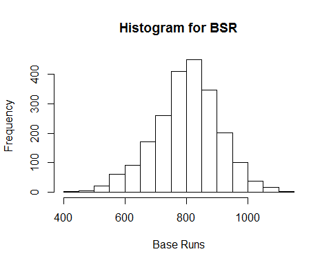

Since BSR is a combination of all of the batting variables, we simply eliminated them and created a very strong model on the first iteration. All p-values were very low, and the variation are all below 5 showing no probems with collinearity. The characteristic equation indicated by the model is as follows:

| Coefficient | Variable |
| --- | --- |
| 40.687320 | Intercept |
| + 0.062189 | BSR |
| - 0.116615 | TEAM_FIELDING_DP |
| - 0.058885 | TEAM_FIELDING_E |
| + 0.060347 | TEAM_BASERUN_SB |
| - 0.011457 | TEAM_PITCHING_SO |
| + 0.019419 | TEAM_PITCHING_H |
| - 0.017603 | TEAM_PITCHING_BB |

| RSE | R^2 | Adj. R^2 | F Stat. | MSE |
| --- | --- | --- | --- | --- |
| 11.99 | 0.3229 | 0.3207 | 147.4 | 144 |

The coefficients for this model overall do make sense. Errors and pitching walks contribute to fewer wins, and stolen bases and the BSR metric have strong influence on increasing wins. Double plays do have a slightly negative value, although this could be explained by a team allowing a large number of baserunners, and in anay case this matches the relationship of the data when you compare against target wins. The positive impact of allowing pitching hits was puzzling, but once again it agrees with the trends we see in the data provided.

**————————————————————————————————————————–**

## Model 5: Box-Cox First

This model first applied transformations to a simple regression of each predictor against wins and showed improvements in the normality of the distribution and more uniformly distributed residuals. In each case a Box-Cox transformation was applied to improve the skewness of predictor variables prior to becoming candidates for the multi-regression model.

The model then applied a simple Forward Selection strategy, adding variables two-at-a-time until none can be found that improve the model as measured by adjusted $R^2$.

Pre-model transformation of individual predicotor variables were as follows:

- TEAM_PITCHING_BB (boxcox-transform) $\lambda$ => y^(1/6)
- TEAM_BATTING_1B (derived variable) => TEAM_BATTING_H - TEAM_BATTING_2B - TEAM_BATTING_3B - TEAM_BATTING_HR, (boxcox-transform) $\lambda$ => 1/(y^2)
- SLUGGING (derived variable) => 2 * TEAM_BATTING_3B + TEAM_BATTING_HR y^(3/5)
- TEAM_BATTING_SB (boxcox-transform) $\lambda$ => y^(-1/25)
- FIELDING YIELD (derived variable) => TEAM_FIELDING_E + TEAM_FIELDING_DP y^(-(9/10))
- TEAM_PITCHING_SO (boxcox-transform) $\lambda$ (y^2/3)

SLUGGING & FIELDING YIELD predictors where derived because the underlying variables lacked enough of a normal distribution and residual uniformity to be added to the multi-linear model on their own. These problems were greatly reduced after applying the derivation and Box-Cox transformation.

The Forward Selection method was applied through the use of p-values and variance inflation factors (VIF) against the following predictor variables:

Steps were as follows:

- Start with p.Hits & p.Walks
- Added b.Singles & b.Slugging
- Added Stolen Bases and Fielding
- Removed p.Hits
- Added b.Walks and p.Strikeouts
- Remove b.Walks

The diagnostic plots of that model show relatively good linearity between the response variable TARGET_WINS and the 6 predictor variable as evidenced in the Added Variable plots shown in the Appendix. Furthermore, the plots of standardized residuals against each of the predictor variables showed evidence of relatively uniform variability for each variable except the derived predictor FIELDING which has two clusters.

Note that by combining TEAM_FIELDING_DP and TEAM_FIELDING_E into FIELDING using a Box-Cox transform $\lambda$ => 1/(y^2) on the derived field prior to adding FIELDING to the model, variablity was somewhat improved and the clustering effect was somewhat mitigated.

Pre-model transformation of individual predicotor variables were then adjusted as follows:

- TEAM_PITCHING_BB
- TEAM_BATTING_1B (derived variable) => TEAM_BATTING_H - TEAM_BATTING_2B - TEAM_BATTING_3B - TEAM_BATTING_HR
- SLUGGING (derived variable)
- TEAM_BATTING_SB
- FIELDING YIELD (derived variable) => TEAM_FIELDING_E + TEAM_FIELDING_DP
- TEAM_PITCHING_SO

| Coefficient | Variable |
| --- | --- |
| 78.730 | Intercept |
| + 28.760 | 1/(TEAM_PITCHING_BB^6) |
| - 21.360 | 1/(TEAM_BATTING_1B^2) |
| + 1.450 | (SLUGGING^3) / (SLUGGING^5) |
| - 125.800 | 1/(TEAM_BATTING_SB^25) |
| + 3.747e6 | (FIELDING^10) / (FIELDING^9) |
| - .1037 | (TEAM_PITCHING_SO^2) / (TEAM_PITCHING_SO^3) |

| RSE | R^2 | Adj. R^2 | F Stat. | MSE |
| --- | --- | --- | --- | --- |
| 11.97 | 0.3142 | 0.3123 | 164.2 | 143 |

The sign and magnitude of each coefficient is the result of the transformations as well as the linear model, so it appears that reading the coeffiecients becomes less intuitively tied to the linear relationship between predictors and variables as the extent of transformations increase. This does not invalidate the model, it simply means the coefficents become less useful as a check of the model’s fidelity.

**————————————————————————————————————————–**

# Part 4. Select Models

The chart below summarizes the model statistics for all five of our models. The models are listed from left to right in accordance with the order in which they were described in **Part 3** herein (Models 1-5). Please refer to the Appendix for detailed descriptions, diagnostic plots, and procedural details on the derivation of each of these models.

[output not shown]

Each of our five models converged on similar $R^2$ values, RSE’s, and MSE’s, and all yielded residuals that were distributed normally without signficant evidence of highly leveraged outliers. No signficant collinearity exists within any of the five models for any of their component predictor variables.

Of the five, the General Model had the least favorable residual characteristics, with multiple predictors showing non-constant variability relative to the residuals, while having a relatively low F-statistic when compared to the other models.

Of the remaining four models, the Total Bases model was a great improvement over the General Model. However, it too displayed some lack of constant variability of residuals relative to a couple of the predictor variables.

The Box-Cox First model makes use of a recommended Box-Cox transform for each individual predictor variable before the linear model is constructed via forward selection. While this model yielded results similar to the others, it was deemed to be overly complex both for the number of variables that comprised the model and the difficulty we would have explaining the predictor coefficients.

Therefore, **we selected the TB PLUS model** as the basis for our prediction of TARGET_WINS for the Evaluation data set. To ensure the model’s efficacy when applied to the Evaluation data set, we first applied a set of transformations to that data set that were identical to those applied to the Training data set during the development of the TB PLUS model. The TB PLUS model was then applied to yield a set of INDEX / TARGET_WINS pairs.

Since displaying the full set of predicted values would consume a large number of pages herein, a sample of the first 10 rows of that data set is displayed below:

| INDEX | TARGET_WINS |
| --- | --- |
| 9 | 61 |
| 10 | 66 |
| 14 | 72 |
| 47 | 86 |
| 60 | 66 |
| 63 | 73 |
| 74 | 82 |
| 83 | 71 |
| 98 | 69 |
| 120 | 74 |

The full set of predicted TARGET_WINS can be found at the following web link:

https://github.com/spsstudent15/2016-02-621-W1/blob/master/HW1-PRED-EVAL-WINS-ONLY.csv

**————————————————————————————————————————–**

# Part 5. References

## Bibliography

Diez, D.M., Barr, C.D., & Cetinkaya-Rundel, M. (2015). OpenIntro Statistics, Third Edition. Open Source. Print

Faraway, J. J. (2015). Extending linear models with R, Second Edition. Boca Raton, Fla: Chapman & Hall/CRC. Print

Faraway, J. J. (2015). Linear models with R, Second Edition. Boca Raton, Fla: Chapman & Hall/CRC. Print

Fox, John (2016). Applied Regression Analysis and Generalized Linear Models, Third Edition. Los Angeles: Sage. Print.

Sheather, Simon J. (2009). A Modern Approach to Regression with R. New York, NY: Springer. Print

## Resource Links

http://www.baseball-almanac.com/

https://raw.githubusercontent.com/spsstudent15/2016-02-621-W1

http://tangotiger.net/wiki_archive/Base_Runs.html